Please provide your names, last names, and student IDs.

- name 1, last name 1, student id 1 Aksenyuk Sofya, 150284
- name 2, last name 2, student id 2 Górecki Piotr, 148282

# DECISION TREES

**Important note: this exercise uses Pandas (for data manipulation and analysis) and Graphviz (for graph-drawing) libraries.**

This exercise consists of 3 parts. Complete the first part to get a mark of 3.0, the first two parts to get 4.0, complete all assignments to get 5.0.

```python
%matplotlib inline
import numpy as np
import math
import matplotlib.pyplot as plt
import pandas as pd
import common as cm
```

# Part 1: Information Gain

1.1 ) There are 10 objects (data) characterized with 5 binary attributes:

```python
attributeNames = ["attr 1", "attr 2", "attr 3", "attr 4", "attr 5"]

data = pd.DataFrame(
    [
        [1, 0, 1, 1, 1],
        [1, 1, 0, 0, 1],
        [0, 1, 1, 1, 1],
        [1, 0, 1, 0, 1],
        [1, 0, 0, 1, 1],
        [0, 0, 1, 1, 1],
        [1, 1, 1, 1, 1],
        [1, 0, 0, 1, 1],
        [0, 1, 0, 0, 1],
        [0, 0, 0, 1, 1],
    ],
    columns=attributeNames,
)
```

1.2) Each object is assigned to either a class "0" or "1". The assignments are as follows (cl):

```python
data["cl"] = [1, 1, 1, 0, 0, 1, 1, 1, 0, 0]
```

Hint: How one can read data (columns) in Pandas

```python
print(data["cl"])
print(list(data["cl"]))
print(set(data["cl"]))
print(data["attr 1"])
```

```
0    1
1    1
2    1
3    0
4    0
5    1
6    1
7    1
8    0
9    0
Name: cl, dtype: int64
[1, 1, 1, 0, 0, 1, 1, 1, 0, 0]
{0, 1}
0    1
1    1
2    0
3    1
4    1
5    0
6    1
7    1
8    0
9    0
Name: attr 1, dtype: int64
```

1.3 ) Finish the below function for calculating entropy. $H(CL) = - \sum_{y \in CL}p(y)log_2p(y)$ It should return a value of entropy for an input vector CL. Assume that $log_2(0)$ is equal to 0.

```python
def getEntropy(cl):
    ### TODO
    count_1 = 0
    for i in range(len(cl)):
        if cl[i] == 1:
            count_1 += 1
    p1 = count_1 / len(cl)
    p0 = 1 - p1

    if p0 == 0:
        log_p0 = 0
    else:
        log_p0 = math.log(p0, 2)
    if p1 == 0:
        log_p1 = 0
    else:
        log_p1 = math.log(p1, 2)
    H = (-1) * p0 * log_p0 + (-1) * p1 * log_p1
    return H
    ### return 0
```

1.4 ) Calculate the entropy for the CL vector (the result should be 0.97095....):

```python
### TODO print()
print(getEntropy(data["cl"]))
```

```
0.9709505944546686
```

1.5) Finish the below function for calculating a conditional entropy: $H(CL|X) = - \sum_{x \in X} \sum_{y \in CL} p(x,y) log_2 \frac{p(x,y)}{p(x)}$. Assume that $log_2(0)$ is equal to 0 and if $p(x) = 0$, $\frac{p(x,y)}{p(x)}$ is equal to 0 as well.

```python
def getConditionalEntropy(cl, attr):
    ## TODO
    count_x0_cl0 = 0
    count_x0_cl1 = 0
    count_x1_cl0 = 0
    count_x1_cl1 = 0
    list_attr = list(attr)
    list_cl = list(cl)
    for i in range(len(list_attr)):
        if (list_attr[i] == 0) and (list_cl[i] == 0):
            count_x0_cl0 += 1
        if (list_attr[i] == 0) and (list_cl[i] == 1):
            count_x0_cl1 += 1
        if (list_attr[i] == 1) and (list_cl[i] == 0):
            count_x1_cl0 +=1
        if (list_attr[i] == 1) and (list_cl[i] == 1):
            count_x1_cl1 += 1

    x_1 = 0
    for i in range(len(list_attr)):
        if list_attr[i] == 1:
            x_1 += 1
    x_0 = len(list_attr) - x_1
    if x_0 == 0:
        p_x0_cl0 = 0
        p_x0_cl1 = 0
    else:
        p_x0_cl0 = count_x0_cl0 / x_0
        p_x0_cl1 = count_x0_cl1 / x_0
    if x_1 == 0:
        p_x1_cl0 = 0
        p_x1_cl1 = 0
    else:
        p_x1_cl0 = count_x1_cl0 / x_1
        p_x1_cl1 = count_x1_cl1 / x_1

    if p_x0_cl0 == 0:
        log_px0cl0 = 0
    else:
        log_px0cl0 = math.log(p_x0_cl0, 2)
    if p_x0_cl1 == 0:
        log_px0cl1 = 0
    else:
        log_px0cl1 = math.log(p_x0_cl1, 2)
    if p_x1_cl0 == 0:
        log_px1cl0 = 0
    else:
        log_px1cl0 = math.log(p_x1_cl0, 2)
    if p_x1_cl1 == 0:
        log_px1cl1 = 0
    else:
        log_px1cl1 = math.log(p_x1_cl1, 2)

    H_x0 = (-1) * p_x0_cl0 * log_px0cl0 + (-1) * p_x0_cl1 * log_px0cl1
    H_x1 = (-1) * p_x1_cl0 * log_px1cl0 + (-1) * p_x1_cl1 * log_px1cl1
    H_x = (x_0/len(list_cl)) * H_x0 + (x_1/len(list_cl)) * H_x1

    return H_x
```

1.6 ) Calculate conditional entropies for given attribiutes.

```python
print(getConditionalEntropy(data["cl"], data["attr 1"])) ### the result should be 0.95097...
print(getConditionalEntropy(data["cl"], data["attr 5"])) ### the result should be 0.97095...
```

```
0.9509775004326937
0.9709505944546686
```

1.7 ) **Question: Which entropy is lesser and why?** Answer: The entropy for "attr 1" is lesser, because the smaller value we get - the higher level of order we have.

1.8) Finish the below function for calculating information gain (use getEntropy() and getConditionalEntropy() functions):

```python
def getInformationGain(cl, attr):
    ### TODO
    gain = getEntropy(cl) - getConditionalEntropy(cl, attr)
    if gain == -0.0:
        gain = 0.0
    return gain
    ### return 0.0
```

```python
print(getInformationGain(data["cl"], data["attr 1"]))
print(getInformationGain(data["cl"], data["attr 5"]))
```

```
0.01997309402197489
0.0
```

1.9) **Question: Which IG is lesser and why?** Answer: The IG for "attr 5" is lesser, because the higher value we get - the more effective that attribute in classifying training data.

# Part 2: ID3 algorithm

Decision tree consists of decision nodes and leaves. Nodes split data while leaves classify objects. Consider the class "Node" provided below. It consists of 4 fields:

- attr - attribute ID (use the names in attributeNames vector)
- left - left branch, i.e., a reference to other node
- right - right branch, i.e., a reference to other node
- value - a decision. If node = None, then the node is not a leaf. If value is not None, then a node is considered a leaf.

Method **call** returns the decision if the node is a leaf (i.e., when value is not None). Otherwise, it calls either the left or the right branch of an input object, based on the attribute value (0 -> left children; 1 -> right children). In this way, we can traverse the decision tree in order to find the final decision.

**Analyze the example code**

```python
class Node:
    def __init__(self, attr, left, right, value):
        self.attr = attr
        self.left = left
        self.right = right
        self.value = value

    def __call__(self, obj):
        if self.value is None:
            if obj[self.attr] == 0:
                return self.left(obj)
            else:
                return self.right(obj)
        else:
            return self.value

### EXAMPLE
def example(obj):
    root = Node(0, None, None, None) ###  IN ROOT SPLIT ON 1ST (0) ATTRIBUTE
    lChildren = Node(1, None, None, None) ### IN ROOT's LEFT CHILDREN SPLIT ON 2ND (1) ATTRIBUTE
    rChildren = Node(None, None, None, 2) ### IN ROOT's RIGHT CHILDREN -> DECISION = 2
    root.left = lChildren
    root.right = rChildren
    llChildren = Node(None, None, None, 3) ### IN ROOT's LEFT-LEFT CHILDREN -> DECISION = 3
    lrChildren = Node(None, None, None, 4) ### IN ROOT's LEFT-RIGHT CHILDREN -> DECISION = 4
    lChildren.left = llChildren
    lChildren.right = lrChildren
    print(root(obj))

example([0, 0]) ### ROOT : FIRST ATTRIBUTE = 0 SO WE GO TO LEFT CHILDREN.
### THEN, IN THE CORRESPONDING CHILDREN, THE SECOND ATTRIBUTE = 0, SO WE GO TO LEFT-LEFT CHILDREN.
### IT IS A LEAF WITH THE DECISION = 3.

example([0, 1])
example([1, 0])
example([1, 1])
```

```
3
4
2
2
```

2.1) Create an initial root. Set the value (decision) to 1.

```python
root = Node(None, None, None, 1)
```

2.2) Use a getErrorRate method in common.py auxiliary file to calculate the error rate. The decision is made based on the majority rule. In case of tie, the method takes 0 as the default class.

```python
### TODO
cm.getErrorRate(root, data)

# ## SHOULD BE 0.4
```

```
0.4
```

2.3) Use printGraph method (see the common.py file) to draw the decision tree and save it in a png file.

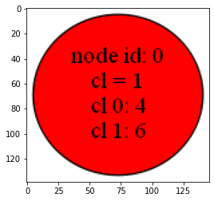

```python
cm.printGraph(root, data, fileName='decision_tree_0')
plt.imshow(plt.imread("decision_tree_0.png"))
```

2.4) Calculate information gain for all attribiutes.

```python
def printInformationGain(data):
    for attribute_name in attributeNames:
        ### TODO
        print(getInformationGain(data["cl"], data[attribute_name]))

printInformationGain(data)
```

```
0.01997309402197489
0.0464393446710154
0.12451124978365313
0.0912774462416801
0.0
```

2.5) Choose the best attribute to split the data (HINT, it should be the third attribute :)). Construct two new nodes: one for $x_i$ = 0 decision and the second for $x_i$ = 1; connect them with the root (left and right branch). Remember to update the root.

```python
### TODO
zero_Node = Node(None,None,None,0)
one_Node = Node(None,None,None,1)
root.attr = "attr 3"
root.value = None
root.left = zero_Node
root.right = one_Node
```

2.6) Print the graph and calculate the error rate. What happened with the error rate?

```
0.30000000000000004
```

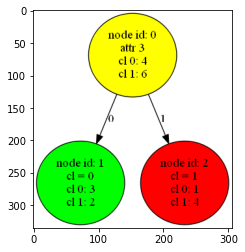

```python
cm.printGraph(root, data, fileName='decision_tree_0')
plt.imshow(plt.imread("decision_tree_0.png"))
cm.getErrorRate(root, data)
```

2.7) Split the 'data' (table) based on the selected attribiute, i.e., create two new tables.

```python
left_data = data[data['attr 3']==0]
right_data = data[data['attr 3']==1]
print(left_data)
print(right_data)
```

```
   attr 1  attr 2  attr 3  attr 4  attr 5  cl
1       1       1       0       0       1   1
4       1       0       0       1       1   0
7       1       0       0       1       1   1
8       0       1       0       0       1   0
9       0       0       0       1       1   0
   attr 1  attr 2  attr 3  attr 4  attr 5  cl
0       1       0       1       1       1   1
2       0       1       1       1       1   1
3       1       0       1       0       1   0
5       0       0       1       1       1   1
6       1       1       1       1       1   1
```

2.8) Let us start with the left node. Firstly, calculate information gain for this node.

```python
### TODO
print(getInformationGain(list(left_data['cl']), left_data['attr 1']))
print(getInformationGain(list(left_data['cl']), left_data['attr 2']))
print(getInformationGain(list(left_data['cl']), left_data['attr 3']))
print(getInformationGain(list(left_data['cl']), left_data['attr 4']))
print(getInformationGain(list(left_data['cl']), left_data['attr 5']))
```

```
0.4199730940219749
0.01997309402197489
0.0
0.01997309402197489
0.0
```

2.9) Choose the best attribute to split the data and then update the decision tree.

```python
### TODO
zero_Node.attr = "attr 1"
znlc = Node(None,None,None,0)
znrc = Node(None,None,None,1)
zero_Node.value = None
zero_Node.left = znlc
zero_Node.right = znrc
```

2.10) Print the graph and calculate the error rate (hint: should be 0.2 :). What happened with the error rate?

```
0.19999999999999996
```

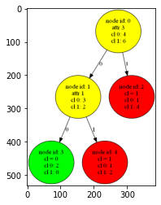

```python
### TODO
cm.printGraph(root, data, fileName='decision_tree_0')
plt.imshow(plt.imread("decision_tree_0.png"))
cm.getErrorRate(root, data)
```

2.11) Split data (remember that we split left_data, not data).

```python
#TODO
leftLeft_data = left_data[left_data['attr 1']==0]
leftRight_data = right_data[right_data['attr 1']==1]
print(leftLeft_data)
print(leftRight_data)
```

```
   attr 1  attr 2  attr 3  attr 4  attr 5  cl
8       0       1       0       0       1   0
9       0       0       0       1       1   0
   attr 1  attr 2  attr 3  attr 4  attr 5  cl
0       1       0       1       1       1   1
3       1       0       1       0       1   0
6       1       1       1       1       1   1
```

2.12) Repeat the whole process for the right node.

```python
# TODO compute the information gain
print(getInformationGain(list(right_data['cl']), right_data['attr 1']))
print(getInformationGain(list(right_data['cl']), right_data['attr 2']))
print(getInformationGain(list(right_data['cl']), right_data['attr 3']))
print(getInformationGain(list(right_data['cl']), right_data['attr 4']))
print(getInformationGain(list(right_data['cl']), right_data['attr 5']))
```

```
0.17095059445466865
0.17095059445466865
0.0
0.7219280948873623
0.0
```

```python
# TODO update the decision tree
one_Node.attr = "attr 4"
onlc = Node(None,None,None,0)
onrc = Node(None,None,None,1)
one_Node.value = None
one_Node.left = onlc
one_Node.right = onrc
```

```
0.09999999999999998
```

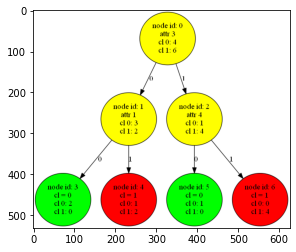

```python
# TODO print the decision tree and calculate the error rate (hint, should be 0.1:) )
cm.printGraph(root, data, fileName='decision_tree_0')
plt.imshow(plt.imread("decision_tree_0.png"))
cm.getErrorRate(root, data)
```

```python
# TODO split the data (right_data)
rightLeft_data = right_data[right_data['attr 4']==0]
rightRight_data = right_data[right_data['attr 4']==1]
print(rightLeft_data)
print(rightRight_data)
```

```
   attr 1  attr 2  attr 3  attr 4  attr 5  cl
3       1       0       1       0       1   0
   attr 1  attr 2  attr 3  attr 4  attr 5  cl
0       1       0       1       1       1   1
2       0       1       1       1       1   1
5       0       0       1       1       1   1
6       1       1       1       1       1   1
```

2.13) Let's consider left-left node. Calculate information gain for it.

```python
# TODO
print(getInformationGain(list(leftLeft_data['cl']), leftLeft_data['attr 1']))
```

```
0.0
```

2.14) Will adding a new node to the tree improve its effectiveness? Why? Why not?

ANSWER : There is no need to add a new node because the InformationGain for left-left, right-left and right-right leaf is set to 0.0, thus meaning there is nothing to iterate over anymore. It will not improve its effectiveness due to the sufficient superiority of attributes assigned to a class

2.15) Calculate information gain for the left-right node.

```python
print(getInformationGain(list(leftRight_data['cl']), leftRight_data['attr 1']))
print(getInformationGain(list(leftRight_data['cl']), leftRight_data['attr 2']))
print(getInformationGain(list(leftRight_data['cl']), leftRight_data['attr 3']))
print(getInformationGain(list(leftRight_data['cl']), leftRight_data['attr 4']))
print(getInformationGain(list(leftRight_data['cl']), leftRight_data['attr 5']))
```

```
0.0
0.2516291673878229
0.0
0.9182958340544896
0.0
```

```python
### Select the attribute and update the tree
znrc.attr = "attr 4"
znlc_l = Node(None,None,None,0)
znrc_r = Node(None,None,None,1)
znrc.value = None
znrc.left = znlc_l
znrc.right = znrc_r
```

```
0.19999999999999996
```

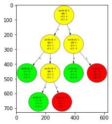

```python
### Print the decision tree and compute the error rate
cm.printGraph(root, data, fileName='decision_tree_0')
plt.imshow(plt.imread("decision_tree_0.png"))
cm.getErrorRate(root, data)
```

2.16) What happened with the error rate? Is it necessary to keep these two newly added leaves? Answer: It is unnecessary to keep added leaves as the error rate went up, therefore it is the best practice to leave the iteration at a stable, low error rate.

2.17) Finish creating the right side of the tree

ANSWER : You cannot split the tree anymore.

```python
### TODO
```

# Part 3: automated construction of decision trees

**3.1 REMARK: the difficulty of this exercise is high**. Complete the following function for automated construct of decision trees, so that it returns a decision tree for the given data and attribute list. Note that this is a recusive method, i.e., calls itself.

```python
max_depth = 0

def createTree(data, attributeNames, depth=0):
    data = data.reset_index().drop("index", axis=1)
    ### TODO
```

3.2) Build a decision tree for a training dataset in the common.py auxiliary file, for diffrent values of max_depth. Calculate & compare the error rates for training and validation datasets.

```python
max_depth = 10
```

```python
train_attributeNames, train_data = cm.getTrainingDataSet()
### TODO - TRAINING DATASET
```

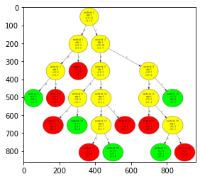

```python
### SEE THE EXPECTED RESULT TRAIN_TREE.PNG IN THE FILES BUNDLE.
plt.imshow(plt.imread("train_tree_expected.png"))
```

```python
valid_attributesName, valid_data = cm.getValidationDataSet()
### TODO - VALIDATION DATASET
```

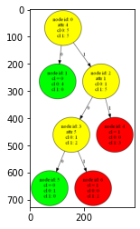

```python
### SEE THE EXPECTED RESULT TRAIN_TREE.PNG IN THE FILES BUNDLE.
plt.imshow(plt.imread("validation_tree_expected.png"))
```

3.3) Consider only the training data set and answer the following questions:

- What is the miximum depth of the tree (consider only the training data set)?
- The tree building process should stop when there is no improvement in error rate (why?). Check for which value of "max_dept" there is no improvement in error rate.

```python
for i in range(10):
    max_depth = i
    ### TODO
```